# Übungen A

RaumAn2

RaumAn

Analyse von Punktverteilungen

Patrick Laube , Nils Ratnaweera , Nikolaos Bakogiannis  
08-19-2021

Importiere zunächst die Daten. Weise dann die korrekten Koordinatensysteme zu (CRS *zuweisen*).

- luftqualitaet.gpkg: Luftqualitätsmessungen NO2, ([weitere Informationen](https://opendata.swiss/en/dataset/luftqualitaet))
- kantone.gpkg: Ein Datensatz der Swisstopo ([weitere Informationen](https://shop.swisstopo.admin.ch/de/products/landscape/boundaries3D))
- rotmilan.gpkg: Der Datensatz `rotmilan.gpkg` stammt aus einem grösseren Forschungsprojekt der Vogelwarte Sempach [Mechanismen der Populationsdynamik beim Rotmilan](https://www.vogelwarte.ch/de/projekte/oekologische-forschung/mechanismen-der-populationsdynamik-beim-rotmilan). Der Datensatz wurde über die Plattform [movebank](http://www.movebank.org/panel_embedded_movebank_webapp?gwt_fragment=page%3Dsearch_map_linked%2CindividualIds%3D676571254%2Clat%3D44.465151013519666%2Clon%3D9.096679687499508%2Cz%3D5) zur Verfügung gestellt. Es handelt sich dabei um ein einzelnes Individuum, welches seit 2017 mit einem Sender versehen ist und über ganz Mitteleuropa zieht. Wir arbeiten in dieser Übung nur mit denjenigen Datenpunkten, die in der Schweiz erfasst wurden. Wer den ganzen Datensatz analysieren möchte, kann sich diesen über den Movebank-Link runterladen.

```r
library(gstat)
library(sf)
library(tidyverse)
library(lubridate)
library(stars)

luftqualitaet <- read_sf("luftqualitaet.gpkg")
kantone <- read_sf("kantone.gpkg")
rotmilan <- read_sf("rotmilan.gpkg")


luftqualitaet <- st_set_crs(luftqualitaet,2056)
kantone <- st_set_crs(kantone, 2056)
rotmilan <- st_set_crs(rotmilan, 2056)
```

Als erstes berechnen wir die G-Function für die Rotmilanpositionen wie auch für die Luftqualitätsmessungen NO2:

```r
rotmilan_sample <- sample_n(rotmilan,1000)
```

**Schritt 2:** Mit `st_distance()` können Distanzen zwischen zwei `sf` Datensätze berechnet werden. Wird nur ein Datensatz angegeben, wird eine Kreuzmatrix erstellt wo die Distanzen zwischen allen Features zu allen anderen Features dargestellt werden. Wir nützen diese Funktion zur Berechnung der nächsten Nachbarn.

```r
rotmilan_distanzmatrix <- st_distance(rotmilan_sample)

# zeige die ersten 6 Zeilen und Spalten der Matrix
# jeder Distanz wurde 2x Gemessen (vergleiche Wert [2,1] mit [1,2])
# die Diagonale ist die Distanz zu sich selber (gleich 0)
rotmilan_distanzmatrix[1:6,1:6]
```

```
Units: [m]
           [,1]       [,2]     [,3]       [,4]       [,5]     [,6]
[1,]     0.0000 50170.0909 45837.60 49567.8422   233.6383 65393.70
[2,] 50170.0909     0.0000 27001.53   813.0507 49941.9140 17327.44
[3,] 45837.6022 27001.5284     0.00 26255.6380 45617.9616 42689.53
[4,] 49567.8422   813.0507 26255.64     0.0000 49339.1279 18131.04
[5,]   233.6383 49941.9140 45617.96 49339.1279     0.0000 65175.15
[6,] 65393.7008 17327.4429 42689.53 18131.0375 65175.1529     0.00
```

**Schritt 3:** Nun wollen wir wissen, wie gross die kürzeste Distanz von jedem Punkt zu seinem nächsten Nachbarn beträgt, also die kürzeste Distanz pro Zeile. Zuerst aber müssen wir die diagonalen Werte noch entfernen, denn diese stellen ja jeweils die Distanz zu sich selber dar und sind immer `0`. Danach kann mit `apply()` eine Funktion (`FUN = min`) über die Zeilen (`MARGIN = 1`) einer Matrix (`X = rotmilan_distanzmatrix`) gerechnet werden. Zusätzlich müssen wir noch `na.rm = TRUE` setzen, damit `NA` Werte von der Berechnung ausgeschlossen werden. Das Resultat ist ein Vektor mit gleich vielen Werten wie Zeilen in der Matrix.

```r
diag(rotmilan_distanzmatrix) <- NA # entfernt alle diagonalen Werte

rotmilan_mindist <- apply(rotmilan_distanzmatrix,1,min, na.rm = TRUE)
```

Nun wollen wir die kumulierte Häufigkeit der Werte in einer Verteilungsfunktion (engl: [Empirical Cumulative Distribution Function, ECDF](https://en.wikipedia.org/wiki/Empirical_distribution_function)) darstellen. Dafür müssen wir den Vektor zuerst noch in einen Dataframe packen, damit `ggplot` damit klar kommt:

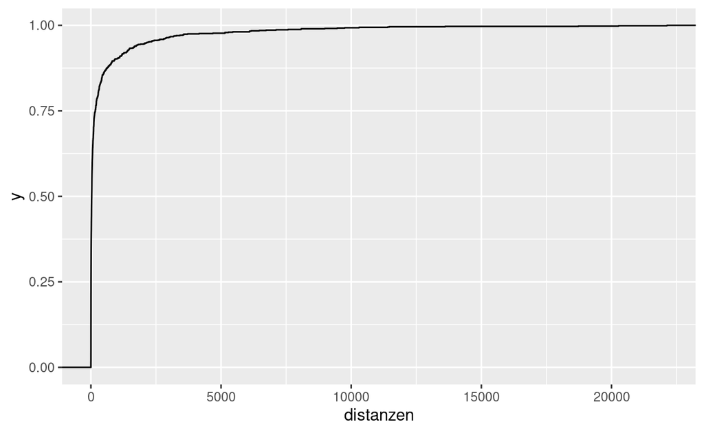

```r
rotmilan_mindist_df <- data.frame(distanzen = rotmilan_mindist)

ggplot() + geom_step(data = rotmilan_mindist_df, aes(distanzen),stat = "ecdf")
```

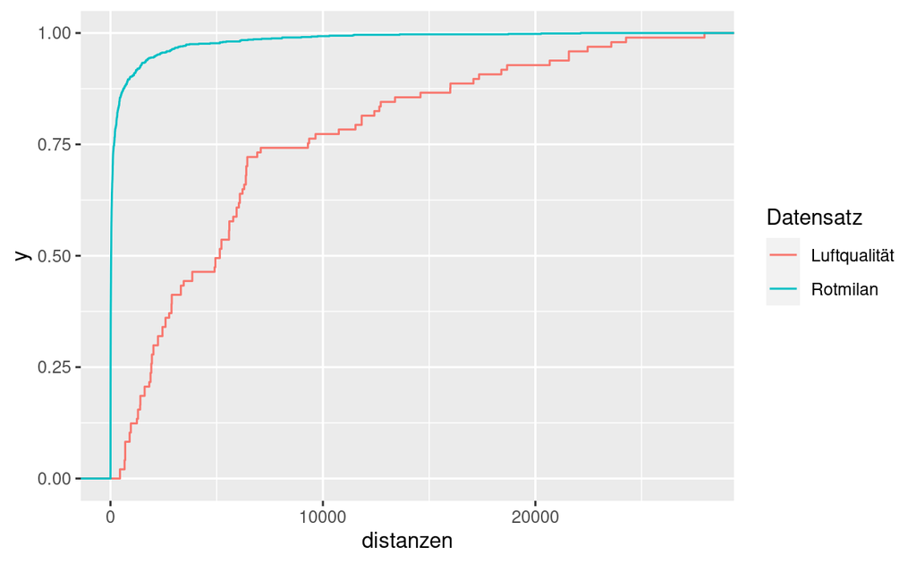

```r
luftqualitaet_distanzmatrix <- st_distance(luftqualitaet)

diag(luftqualitaet_distanzmatrix) <- NA

luftqualitaet_mindist <- apply(luftqualitaet_distanzmatrix,1,min,na.rm = TRUE)

luftqualitaet_mindist_df <- data.frame(distanzen = luftqualitaet_mindist, data = "Luftqualität")

rotmilan_mindist_df$data <- "Rotmilan"

mindist_df <- rbind(luftqualitaet_mindist_df,rotmilan_mindist_df)

ggplot() +
  geom_step(data = mindist_df, aes(distanzen, colour = data),stat = "ecdf") +
  labs(colour = "Datensatz")
```